# BRMS demo

AS Courtin & J Fischer Ehmsen

2025-07-04

This markdown will guide you through the usage of BRMS to fit hierarchical psychometric functions to data generated with the Heart Rate Discrimination Task (HRDT) and the Respiratory Resistance Sensitivity Task (RRST). Here we showcase how to analyze simple within subject experiments with a control and a treatment condition. This demo is a companion of our paper : https://doi.org/10.1101/2025.08.27.672360

# Analyzing Heart Rate Discrimination Task data

## Data simulation (optional)

To demonstrate how to run the hierarchical analysis in BRMS, we first need some data. Therefore, we simulate 50 subjects going through two conditions of a task similar to the HRDT, with the treatment condition leading to an increase of the threshold parameter alpha of five ΔBPM.

*Note: To keep this simulation simple we do not use an adaptive method to optimize stimulus placement based on the responses of the participant. Instead, we simulate responses to 30 trials for each intensity within the pre-selected range (from -40 to +40 ΔBPM in increments of 5). This leads to a rather large total number of trials but the information contained in the dataset is not necessarily much more than in a dataset 10 times smaller with adaptive stimulus placement.*

In case you have real data you want to analyze, you don’t need to go through this step. Instead, make sure you format your data in the same way we use here if you want to reemploy this code.

```r
seed = 12345
set.seed(seed)

# Design
n_subj_HRDT <-50
n_rep_HRDT<-30
x_seq_HRDT <- rep(seq(-40, 40,5),n_rep_HRDT)

# Group-level parameters
mu_lambda_HRDT <- -4.2
sd_lambda_HRDT <- 2

mu_beta_HRDT <- -2.3
sd_beta_HRDT <- 0.3

mu_alpha_HRDT <- -8.6
sd_alpha_HRDT <- 11.6

mu_alpha_dif_HRDT = 5
mu_beta_dif_HRDT = 0

sd_beta_dif_HRDT <- sd_beta_HRDT * 0.5
sd_alpha_dif_HRDT <- sd_alpha_HRDT * 0.5

# Simulate subject-level parameters
subject_base_HRDT <-
  tibble(
    subj = 1:n_subj_HRDT,
    alpha_base = rnorm(n_subj_HRDT, mu_alpha_HRDT, sd_alpha_HRDT),
    lambda_base = rnorm(n_subj_HRDT, mu_lambda_HRDT, sd_lambda_HRDT),
    beta_base = rnorm(n_subj_HRDT, mu_beta_HRDT, sd_beta_HRDT),
    alpha_effect = rnorm(n_subj_HRDT, mu_alpha_dif_HRDT, sd_alpha_dif_HRDT),
    lambda_effect = 0,
    beta_effect = rnorm(n_subj_HRDT, mu_beta_dif_HRDT, sd_beta_dif_HRDT)
  )

# Expand to two conditions
condition_data_HRDT <-
  subject_base_HRDT %>%
  mutate(
    lambda_condition1 = inv_logit(lambda_base) / 2,
    lambda_condition2 = inv_logit(lambda_base + lambda_effect) / 2,

    beta_condition1 = exp(beta_base),
    beta_condition2 = exp(beta_base + beta_effect),

    alpha_condition1 = alpha_base,
    alpha_condition2 = alpha_base + alpha_effect
  ) %>%
  pivot_longer(
    cols = starts_with(c("alpha_", "beta_", "lambda_")),
    names_to = c(".value", "condition"),
    names_pattern = "(.*)_condition(\\d)"
  ) %>%
  drop_na() %>%
  mutate(condition = factor(condition, levels = c("1", "2"), labels = c("control", "treatment")))

# Simulate trials
sim_data_HRDT <-
  condition_data_HRDT %>%
  group_by(subj, condition) %>%
  mutate(x = list(x_seq_HRDT)) %>%
  unnest(x) %>%
  mutate(
    theta = lambda + (1 - 2 * lambda) * (0.5 + 0.5 * pracma::erf(beta * (x - alpha) / sqrt(2))),
    y = rbinom(n(), 1, theta)
  ) %>%
  group_by(subj,condition,x,theta) %>%
  summarise(n=sum(!is.na(y)),y=sum(y))
```

```
## `summarise()` has regrouped the output.
## ℹ Summaries were computed grouped by subj, condition, x, and theta.
## ℹ Output is grouped by subj, condition, and x.
## ℹ Use `summarise(.groups = "drop_last")` to silence this message.
## ℹ Use `summarise(.by = c(subj, condition, x, theta))` for per-operation
##   grouping (`?dplyr::dplyr_by`) instead.
```

Before we proceed, let’s plot the data of our (simulated) participants.

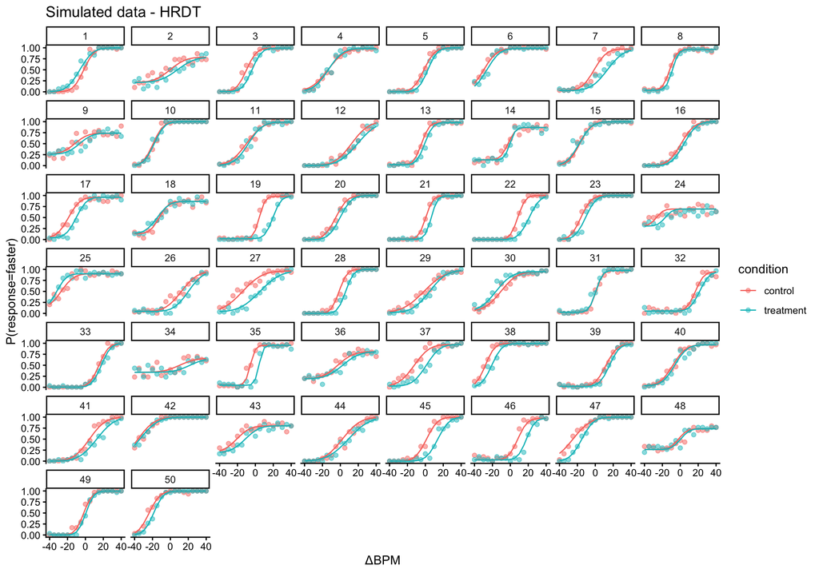

```r
sim_data_HRDT %>%
  ggplot()+
  geom_point(aes(x = x, y = y/n, col = condition),alpha=.5)+
  geom_line(aes(x = x, y = theta, col=condition))+
  facet_wrap(~subj) +
  theme_classic()+
  labs(
    y='P(response=faster)',
    x='ΔBPM',
    title='Simulated data - HRDT'
  )
```

## Model Specification

Now in order to fit this data using BRMS we need to specify a model using *bf()*. In line with the paper, HRDT data is modelled by a Gaussian cumulative density function whose lower and upper asymptotes are set by a lapse rate $\lambda$.

$$\lambda + (1 - 2 \cdot \lambda) \cdot \left(0.5 + 0.5 \cdot
\operatorname{erf}\left( \frac{{\beta}\cdot (x - \alpha)}{\sqrt{2}}
\right) \right)$$

In BRMS syntax, this becomes the following code:

```r
bff_HRDT =
  bf(
    y|trials(n) ~ (inv_logit(lambda) / 2 + (1-inv_logit(lambda)) * (0.5+0.5 * erf(exp(beta)*(x-alpha)/(sqrt(2))))),
    alpha ~ condition + (condition | subj),
    beta ~ condition + (condition | subj),
    lambda~ 1 + (1 | subj),
    nl = TRUE,
    family=binomial(link="identity")
)
```

We have specified random intercepts for all 3 parameters (threshold, slope and lambda) as well as main effects and random slopes for the effects of treatment on the threshold and slope.

We do not specify an effect of treatment on the lapse rate as it is a nuisance parameter. However, we let it vary by subject.

Two of the PF parameters need to be constrained because it would not make sense to let them vary from -Inf to +Inf. First, the slope parameter beta should be strictly positive to make sure the probability of response increases with the intensity of the stimulus. Second, the lapse rate parameter lambda should be constrained to the [0 0.5] range as it reflects the proportion of errors for extreme stimulus intensities. These constraints are enforced by transforms (*exp()* and *inv_logit()/2*) applied directly in the model equation.

Next we need to specify the prior. Here we provide two options: the same weakly informative prior we used for the power analysis or the empirically informed prior we derived from fitting the VMP dataset. In general, we recommend using the empirically informed prior as it should better stabilize sampling and inference.

```r
empirically_informed_priors_HRDT = c(
  set_prior("normal(-8.67,11.23)", class="b", nlpar="alpha", coef = "Intercept"),
  set_prior("normal(0,11.23)", class="b", nlpar="alpha", coef = "conditiontreatment"),
  set_prior("normal(-2.3,0.34)", class="b", nlpar="beta", coef = "Intercept"),
  set_prior("normal(0,0.34)", class="b", nlpar="beta", coef = "conditiontreatment"),
  set_prior("normal(-4.32,1.96)", class="b", nlpar="lambda"),

  set_prior("normal(11.23,0.37*10)", class="sd", nlpar="alpha", group = "subj", lb = 0),
  set_prior("normal(0.34,0.02*10)", class="sd", nlpar="beta", group = "subj", lb = 0),
  set_prior("normal(1.96,0.19)", class="sd", nlpar="lambda", group = "subj", lb = 0)
  )

weakly_informative_priors_HRDT = c(
  set_prior("normal(0,50)", class="b", nlpar="alpha", coef = "Intercept"),
  set_prior("normal(0,10)", class="b", nlpar="alpha", coef = "conditiontreatment"),
  set_prior("normal(-1.3,1.3)", class="b", nlpar="beta", coef = "Intercept"),
  set_prior("normal(0,2)", class="b", nlpar="beta", coef = "conditiontreatment"),
  set_prior("normal(-4,2)", class="b", nlpar="lambda"),

  set_prior("normal(0,10)", class="sd", nlpar="alpha", group = "subj", lb = 0),
  set_prior("normal(0,1.3)", class="sd", nlpar="beta", group = "subj", lb = 0),
  set_prior("normal(0,2)", class="sd", nlpar="lambda", group = "subj", lb = 0)
  )
```

## Model fitting

We can now fit the model to our (simulated) data. Here we include code to fit it with both types of priors but we will focus on the model fit with the empirically informed priors in the rest of this demo.

```r
fit_eip_HRDT <-
  brm(
    bff_HRDT,
    data=sim_data_HRDT,
    chains = 4,
    cores = 4,
    seed = seed,
    backend = "cmdstanr",
    warmup=2000,
    iter=4000,
    control=list(
     adapt_delta=0.9,
     max_treedepth = 10
     ),
    prior = empirically_informed_priors_HRDT
    )
```

[output not shown]

[output cut: 123 more lines]

[output not shown]

```r
# fit_wip_HRDT <-
#   brm(
#     bff_HRDT,
#     data=sim_data_HRDT,
#     chains = 4,
#     cores = 4,
#     seed = seed,
#     backend = "cmdstan",
#     warmup=2000,
#     iter=4000,
#     control=list(
#      adapt_delta=0.9,
#      max_treedepth = 10
#      ),
#     prior = weakly_informative_priors_HRDT
#     )
```

## Model diagnosing

No warning is popping up to tell us something went wrong with the sampler (i.e. problems with max_treedepth, divergent transitions, or E-BFMI). We can therefore have a look at the model. In case such a warning appears on your screen when you are running this code or analyzing your own data please refer to BRMS/Stan documentation (BRMS will give you a link corresponding to the issue you are facing).

```r
fit_eip_HRDT
```

```
##  Family: binomial
##   Links: mu = identity
## Formula: y | trials(n) ~ (inv_logit(lambda)/2 + (1 - inv_logit(lambda)) * (0.5 + 0.5 * erf(exp(beta) * (x - alpha)/(sqrt(2)))))
##          alpha ~ condition + (condition | subj)
##          beta ~ condition + (condition | subj)
##          lambda ~ 1 + (1 | subj)
##    Data: sim_data_HRDT (Number of observations: 1700)
##   Draws: 4 chains, each with iter = 4000; warmup = 2000; thin = 1;
##          total post-warmup draws = 8000
##
## Multilevel Hyperparameters:
## ~subj (Number of levels: 50)
##                                               Estimate Est.Error l-95% CI
## sd(alpha_Intercept)                              12.79      1.24    10.58
## sd(alpha_conditiontreatment)                      5.98      0.72     4.75
## sd(beta_Intercept)                                0.36      0.04     0.28
## sd(beta_conditiontreatment)                       0.18      0.04     0.11
## sd(lambda_Intercept)                              2.09      0.15     1.81
## cor(alpha_Intercept,alpha_conditiontreatment)     0.08      0.15    -0.21
## cor(beta_Intercept,beta_conditiontreatment)      -0.25      0.21    -0.62
##                                               u-95% CI Rhat Bulk_ESS Tail_ESS
## sd(alpha_Intercept)                              15.46 1.00     1219     2116
## sd(alpha_conditiontreatment)                      7.57 1.00     2056     3142
## sd(beta_Intercept)                                0.45 1.00     2572     3433
## sd(beta_conditiontreatment)                       0.26 1.00     2619     3322
## sd(lambda_Intercept)                              2.39 1.00     3001     4435
## cor(alpha_Intercept,alpha_conditiontreatment)     0.37 1.00     1802     2955
## cor(beta_Intercept,beta_conditiontreatment)       0.18 1.00     4372     5211
##
## Regression Coefficients:
##                          Estimate Est.Error l-95% CI u-95% CI Rhat Bulk_ESS
## alpha_Intercept             -6.41      1.77    -9.80    -2.93 1.01      642
## alpha_conditiontreatment     5.38      0.89     3.66     7.14 1.00     1608
## beta_Intercept              -2.27      0.06    -2.38    -2.16 1.00     1772
## beta_conditiontreatment     -0.00      0.04    -0.07     0.07 1.00     4963
## lambda_Intercept            -3.54      0.32    -4.19    -2.93 1.00     1001
##                          Tail_ESS
## alpha_Intercept              1260
## alpha_conditiontreatment     2695
## beta_Intercept               3104
## beta_conditiontreatment      5266
## lambda_Intercept             1906
##
## Draws were sampled using sample(hmc). For each parameter, Bulk_ESS
## and Tail_ESS are effective sample size measures, and Rhat is the potential
## scale reduction factor on split chains (at convergence, Rhat = 1).
```

Before we interpret the results, we need to make sure the posterior has been properly sampled. To do so, we need to check that R-hat values are smaller or equal to 1.01 and effective sample sizes (ESS) values are 400 or more. Once again, the diagnostics are fine (again, if they aren’t on your side, please refer to BRMS/Stan documentation).

checking these can be done with the following code.

```r
bfmi <- function(energy) {
  de <- diff(energy)
  var(de) / var(energy)
}

sp <- get_sampler_params(fit_eip_HRDT$fit, inc_warmup = FALSE)

df <- do.call(rbind, lapply(seq_along(sp), function(i) {
  cbind(as.data.frame(sp[[i]]), chain = i)
}))


df %>% group_by(chain) %>% summarize(number_divergent = sum(divergent__),
                                     low_energy = bfmi(energy__) < 0.3,
                                     max_treedpeth = max(treedepth__))
```

```
## # A tibble: 4 × 4
##   chain number_divergent low_energy max_treedpeth
##   <int>            <dbl> <lgl>              <dbl>
## 1     1                0 FALSE                  8
## 2     2                0 FALSE                  8
## 3     3                0 FALSE                  8
## 4     4                0 FALSE                  8
```

Here we want to see that the number of divergences for each chain is 0 that the low_energy is FALSE for all chains and the max_treedepth is below what we set when running the model (i.e. 10).

## Model interpretation

Our model quantifies the effect of treatment on the threshold parameter alpha and the slope parameter beta of the psychometric function. To test whether there is such an effect, we can extract the posterior mean and 95% credible interval for the group-level difference between conditions and see if 0 is included in the interval. Alternatively, we can compute the posterior probability of this effect being larger than 0 and use this probability to compute a pseudo p-value for a two-sided test (i.e., H0 is that the effect is 0).

We demonstrate these two equivalent approaches in the following code:

```r
summary_stats_HRDT<-
  as_draws_df(fit_eip_HRDT) %>%
  select(b_alpha_Intercept,b_beta_Intercept,b_alpha_conditiontreatment,b_beta_conditiontreatment) %>%
  mutate(
    mean_alpha_treatment=b_alpha_Intercept+b_alpha_conditiontreatment,
    mean_beta_treatment=b_beta_Intercept+b_beta_conditiontreatment
  ) %>%
  rename(
    mean_alpha_control=b_alpha_Intercept,
    mean_beta_control=b_beta_Intercept,
    mean_alpha_diff=b_alpha_conditiontreatment,
    mean_beta_diff=b_beta_conditiontreatment
  ) %>%
  pivot_longer(everything()) %>%
  group_by(name) %>%
  summarise(
    m=mean(value),
    LB=quantile(value,0.025),
    UB=quantile(value,0.975),
    p_larger_than_0=mean(value>0),
    pseudo_p_value=2*min(p_larger_than_0,1-p_larger_than_0)
    )
print(summary_stats_HRDT)
```

```
## # A tibble: 6 × 6
##   name                        m      LB      UB p_larger_than_0 pseudo_p_value
##   <chr>                   <dbl>   <dbl>   <dbl>           <dbl>          <dbl>
## 1 mean_alpha_control   -6.41    -9.80   -2.93           0.00025         0.0005
## 2 mean_alpha_diff       5.38     3.66    7.14           1               0
## 3 mean_alpha_treatment -1.03    -4.90    2.97           0.306           0.612
## 4 mean_beta_control    -2.27    -2.38   -2.16           0               0
## 5 mean_beta_diff       -0.00198 -0.0735  0.0727         0.472           0.943
## 6 mean_beta_treatment  -2.27    -2.38   -2.16           0               0
```

## Reporting the results

If we use the conventional 5% threshold, these results indicate a significant effect of treatment on the threshold parameter alpha but not on the slope parameter beta. This corresponds to the group mean differences that we used to simulate the data, which were 5 and 0 for alpha and beta respectively. We could write something like this to report these results in a paper:

```r
sprintf(
  "Treatment led to a significant increase of the threshold (mean difference [95%% CI]: %0.2f [%0.2f ; %0.2f] ΔBPM, pseudo p-value:  %0.3f), corresponding to a reduced tendency to underestimate one's heart rate (mean threshold for control: %0.2f [%0.2f ; %0.2f]; mean threshold for treatment: %0.2f [%0.2f ; %0.2f]). Conversely, the slope appeared unaffected by treatment (mean log(slope) difference: %0.2f [%0.2f ; %0.2f], pseudo p-value:  %0.3f), suggesting similar precision of judgements made under treatment or control (mean slope for control: %0.2f [%0.2f ; %0.2f]; mean slope for treatment: %0.2f [%0.2f ; %0.2f]).",
  summary_stats_HRDT$m[2],
  summary_stats_HRDT$LB[2],
  summary_stats_HRDT$UB[2],
  summary_stats_HRDT$pseudo_p_value[2],

  summary_stats_HRDT$m[1],
  summary_stats_HRDT$LB[1],
  summary_stats_HRDT$UB[1],

  summary_stats_HRDT$m[3],
  summary_stats_HRDT$LB[3],
  summary_stats_HRDT$UB[3],

  summary_stats_HRDT$m[5],
  summary_stats_HRDT$LB[5],
  summary_stats_HRDT$UB[5],
  summary_stats_HRDT$pseudo_p_value[5],

  exp(summary_stats_HRDT$m[4]),
  exp(summary_stats_HRDT$LB[4]),
  exp(summary_stats_HRDT$UB[4]),

  exp(summary_stats_HRDT$m[6]),
  exp(summary_stats_HRDT$LB[6]),
  exp(summary_stats_HRDT$UB[6])
  )
```

```
## [1] "Treatment led to a significant increase of the threshold (mean difference [95% CI]: 5.38 [3.66 ; 7.14] ΔBPM, pseudo p-value:  0.000), corresponding to a reduced tendency to underestimate one's heart rate (mean threshold for control: -6.41 [-9.80 ; -2.93]; mean threshold for treatment: -1.03 …
```

## Visualization

### Group mean differences

We can then construct plots that show the posterior distribution for the group-level differences in threshold and slope. We will also add a line range materializing the 95% CI.

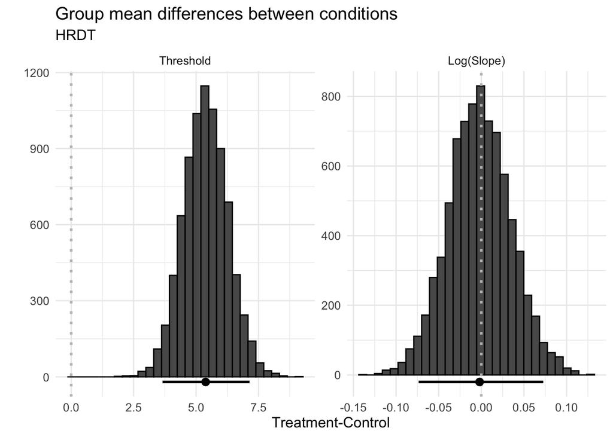

```r
summary_stats_HRDT_plot<-
  summary_stats_HRDT %>%
  filter(grepl('diff',summary_stats_HRDT$name)) %>%
  mutate(name=factor(name,c('mean_alpha_diff','mean_beta_diff'),c('Threshold','Log(Slope)')))


as_draws_df(fit_eip_HRDT) %>%
  select(b_alpha_conditiontreatment,b_beta_conditiontreatment) %>%
  rename(
    mean_alpha_diff=b_alpha_conditiontreatment,
    mean_beta_diff=b_beta_conditiontreatment
  ) %>%
  pivot_longer(everything()) %>%
  mutate(name=factor(name,c('mean_alpha_diff','mean_beta_diff'),c('Threshold','Log(Slope)'))) %>%
  ggplot()+
  geom_histogram(aes(x=value),color='black')+
  geom_vline(aes(xintercept = 0),linetype='dotted',color='grey',linewidth=1)+
  geom_pointrange(data=summary_stats_HRDT_plot,aes(x=m,xmin=LB,xmax=UB,y=-20,group = name),linewidth=1)+
  labs(
    title='Group mean differences between conditions',
    subtitle='HRDT',
    x='Treatment-Control',
    y='')+
  facet_wrap(.~name,scale='free')+
  theme_minimal()+
  theme(
    text=element_text(size = 12)
    )
```

### Group mean PF

To get a better sense of what these values mean, we can also plot the group average PFs.

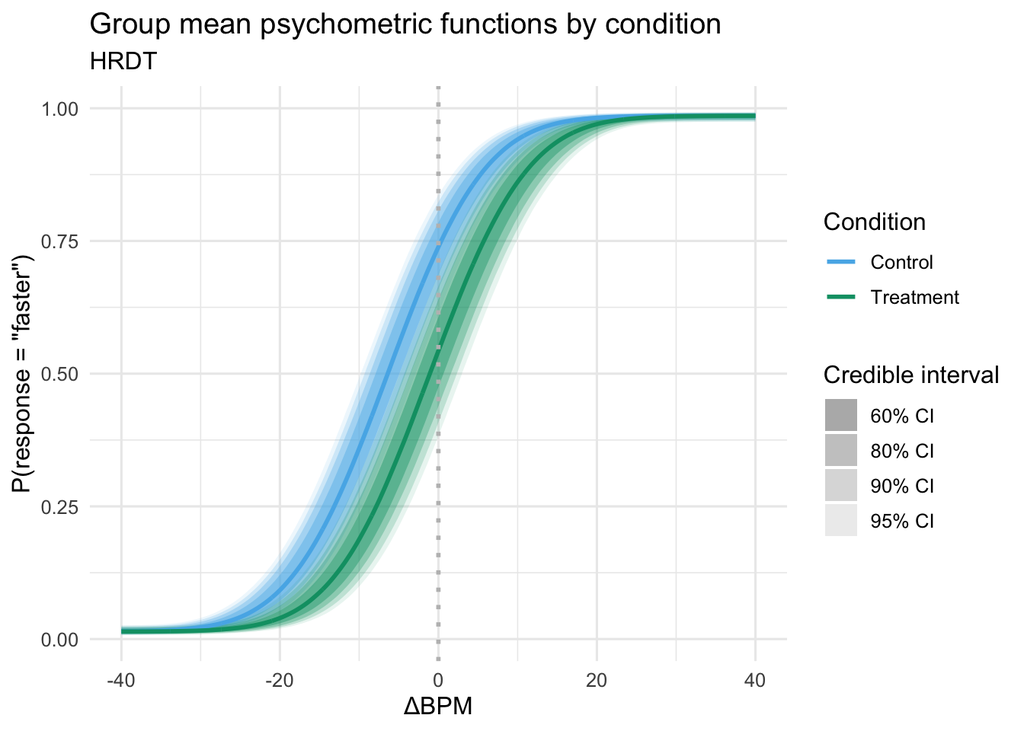

```r
# Get population-level draws
draws <- as_draws_df(fit_eip_HRDT, variable = c(
  "b_alpha_Intercept", "b_alpha_conditiontreatment",
  "b_beta_Intercept", "b_beta_conditiontreatment",
  "b_lambda_Intercept"
)) %>%
  mutate(
    alpha_control = b_alpha_Intercept,
    alpha_treatment = b_alpha_Intercept + b_alpha_conditiontreatment,
    beta_control  = b_beta_Intercept,
    beta_treatment = b_beta_Intercept + b_beta_conditiontreatment,
    lambda = b_lambda_Intercept,
    beta_control = exp(beta_control),
    beta_treatment = exp(beta_treatment),
    lapse = inv_logit(lambda)
  )

# Estimate and summarize PF values at different x
x_seq <- seq(from = -40, to = 40, by = 0.2)
g <- expand.grid(.draw = 1:nrow(draws), x = x_seq, KEEP.OUT.ATTRS = FALSE)
draws$.draw <- 1:nrow(draws)

draw_long <- g %>%
  left_join(draws, by = ".draw") %>%
  mutate(
    p_control = lapse/2 + (1 - lapse) * (0.5 + 0.5 * erf(beta_control * (x - alpha_control) / sqrt(2))),
    p_treatment = lapse/2 + (1 - lapse) * (0.5 + 0.5 * erf(beta_treatment * (x - alpha_treatment) / sqrt(2)))
  ) %>%
  pivot_longer(
    cols = c(p_control, p_treatment),
    names_to = "condition",
    values_to = "p"
  ) %>%
  mutate(
    condition = recode(condition,
                       "p_control" = "Control",
                       "p_treatment" = "Treatment")
  )

# Summarise to CIs
pfs_ppc <- draw_long %>%
  group_by(x, condition) %>%
  summarise(
    s_lb_ci_95 = quantile(p, 0.025),
    s_ub_ci_95 = quantile(p, 0.975),
    s_lb_ci_90 = quantile(p, 0.05),
    s_ub_ci_90 = quantile(p, 0.95),
    s_lb_ci_80 = quantile(p, 0.1),
    s_ub_ci_80 = quantile(p, 0.9),
    s_lb_ci_60 = quantile(p, 0.20),
    s_ub_ci_60 = quantile(p, 0.80),
    m = median(p),
    .groups = "drop"
  ) %>%
  pivot_longer(
    cols = matches("s_(lb|ub)_ci_\\d+"),
    names_to = c("bound", "ci"),
    names_pattern = "s_(lb|ub)_ci_(\\d+)",
    values_to = "value"
  ) %>%
  pivot_wider(names_from = "bound", values_from = "value", names_prefix = "s_")

# Make plot
pfs_ppc %>%
  mutate(
    condition = ordered(condition, levels = c("Control", "Treatment")),
    ci = factor(ci, levels = c("60", "80", "90", "95"))
  ) %>%
  ggplot(aes(x = x)) +
  geom_ribbon(aes(ymin = s_lb, ymax = s_ub, fill = condition, alpha = ci)) +
  geom_line(aes(y = m, color = condition), linewidth = 1) +
  geom_vline(xintercept = 0, linetype = "dotted", color = "grey", linewidth = 1) +
  scale_fill_manual(values = c("#56b4e9", "#009E73")) +
  scale_color_manual(values = c("#56b4e9", "#009E73")) +
  scale_alpha_manual(
    labels = c("60% CI", "80% CI", "90% CI", "95% CI"),
    values = c(.4, .3, .2, .1)
  ) +
  guides(
    fill = "none",
    alpha = guide_legend(order = 2),
    color = guide_legend(order = 1)
  ) +
  labs(
    title="Group mean psychometric functions by condition",
    subtitle="HRDT",
    alpha = "Credible interval",
    color = "Condition",
    x = "ΔBPM",
    y = 'P(response = "faster")'
  ) +
  theme_minimal(base_size = 12)
```

### Individual participant PF

Finally, we should also have a look at individual participants’ psychometric functions to check they align with the data.

```r
pf <- function(x,alpha,beta,lambda){lambda + (1-2*lambda) * (0.5+0.5 * erf(beta*(x-alpha)/(sqrt(2))))}

t<-data.frame(coef(fit_eip_HRDT)$subj[1:n_subj_HRDT,1,]) %>%
  mutate(subj = 1:n_subj_HRDT) %>%
  mutate(
    alpha_control = alpha_Intercept,
    alpha_treatment = alpha_Intercept+alpha_conditiontreatment,
    beta_control = exp(beta_Intercept),
    beta_treatment = exp(beta_Intercept+beta_conditiontreatment),
    lambda = inv_logit(lambda_Intercept) / 2,
  ) %>%
  select(alpha_control,alpha_treatment,beta_control,beta_treatment,lambda,subj) %>%
  pivot_longer(cols=!c(subj,lambda), names_to = c('parameter','condition'),names_sep = '_') %>%
  pivot_wider(names_from = parameter,values_from = value) %>%
  rowwise() %>%
  mutate(x = list(seq(-40,40, by = 1))) %>%
  unnest() %>%
  mutate(p = pf(x,alpha,beta,lambda))
```

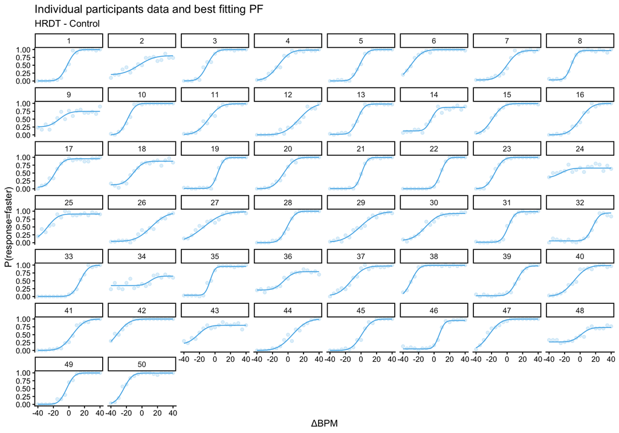

```r
t %>%
  filter(condition=='control') %>%
  ggplot()+
  geom_line(aes(x = x, y = p),col="#56b4e9")+
  geom_point(data = filter(sim_data_HRDT,condition=='control'), aes(x = x, y = y/n,),alpha=.2,col="#56b4e9")+
  facet_wrap(~subj)+
  theme_classic()+
  labs(
    title='Individual participants data and best fitting PF',
    subtitle = 'HRDT - Control',
    y='P(response=faster)',
    x='ΔBPM'
    )
```

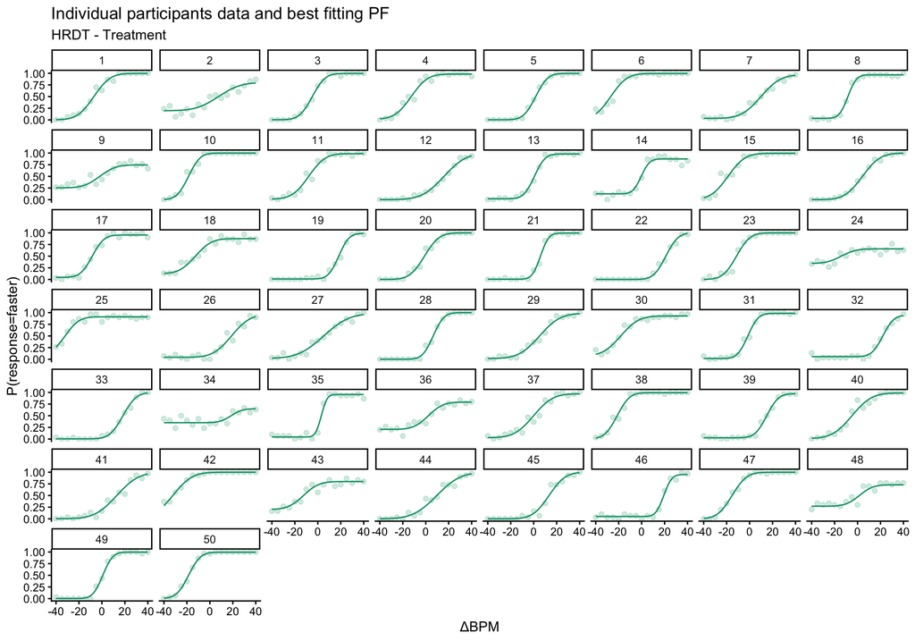

```r
t %>%
  filter(condition=='treatment') %>%
  ggplot()+
  geom_line(aes(x = x, y = p),col="#009E73")+
  geom_point(data = filter(sim_data_HRDT,condition=='treatment'), aes(x = x, y = y/n,),alpha=.2,col="#009E73")+
  facet_wrap(~subj)+
  theme_classic()+
  labs(
    title='Individual participants data and best fitting PF',
    subtitle = 'HRDT - Treatment',
    y='P(response=faster)',
    x='ΔBPM'
    )
```

# Analyzing Respiratory Resistance Sensitivity Task data

This section largely follows the same steps as the one of HRDT data analysis but this time the procedures are adapted to RRST data.

## Data simulation (optional)

To demonstrate how to run the hierarchical analysis in BRMS, we first need some data. Therefore, we simulate 50 subjects going through two conditions of a task similar to the RRST, with the treatment condition leading to a decrease of the threshold parameter alpha of two arbitrary occlusion level (out of 17).

*Note: To keep this simulation simple we do not use an adaptive method to optimize stimulus placement based on the responses of the participant. Instead, we simulate response to 30 trials for each intensity within the pre-selected range (from 1 to 17 arbitrary obstruction levels in increments of 1). This leads to a rather large total number of trials but the information contained in the dataset is not necessarily much more than in a dataset 10 times smaller with adaptive stimulus placement.*

In case you have real data you want to analyze, you don’t need to go through this step. Instead, make sure you format your data in the same way we use here if you want to reemploy this code.

```r
#Set seed to ensure reproducibility
seed = 12345
set.seed(seed)

# Design
n_subj_RRST <- 50
n_rep_RRST<-30
x_seq_RRST <- rep(seq(1, 17,1),n_rep_RRST)

# Group-level parameters
mu_lambda_RRST <- -4.5
sd_lambda_RRST <-2.53

mu_beta_RRST <- 2.1
sd_beta_RRST <- 0.9

mu_alpha_RRST <- 2.6
sd_alpha_RRST <- 0.1

mu_alpha_dif_RRST = log(exp(mu_alpha_RRST)-2)-mu_alpha_RRST
mu_beta_dif_RRST = 0

sd_beta_dif_RRST <- sd_beta_RRST * 0.5
sd_alpha_dif_RRST <- sd_alpha_RRST * 0.5

# Subject-level coefficients
subject_base_RRST <- tibble(
  subj = 1:n_subj_RRST,
  alpha_base = rnorm(n_subj_RRST, mu_alpha_RRST, sd_alpha_RRST),
  lambda_base = rnorm(n_subj_RRST, mu_lambda_RRST, sd_lambda_RRST),
  beta_base = rnorm(n_subj_RRST, mu_beta_RRST, sd_beta_RRST),
  alpha_effect = rnorm(n_subj_RRST, mu_alpha_dif_RRST, sd_alpha_dif_RRST),
  lambda_effect = 0,
  beta_effect = rnorm(n_subj_RRST, mu_beta_dif_RRST, sd_beta_dif_RRST)
)

# Convert subject level coefficients to PF parameters
condition_data_RRST <-
  subject_base_RRST %>%
  mutate(
    lambda_condition1 = inv_logit(lambda_base) / 2,
    lambda_condition2 = inv_logit(lambda_base + lambda_effect) / 2,

    beta_condition1 = exp(beta_base),
    beta_condition2 = exp(beta_base + beta_effect),

    alpha_condition1 = exp(alpha_base),
    alpha_condition2 = exp(alpha_base + alpha_effect)
  ) %>%
  pivot_longer(
    cols = starts_with(c("alpha_", "beta_", "lambda_")),
    names_to = c(".value", "condition"),
    names_pattern = "(.*)_condition(\\d)"
  ) %>% drop_na() %>%
  mutate(condition = factor(condition, levels = c("1", "2"), labels = c("control", "treatment")))

# Simulate trials
sim_data_RRST <-
  condition_data_RRST %>%
  group_by(subj, condition) %>%
  mutate(x = list(x_seq_RRST)) %>%
  unnest(x) %>%
  mutate(
    theta = 0.5 + (0.5 - lambda) * (1-exp(-(x/alpha)^beta)),
    y = rbinom(n(), 1, theta)
  ) %>%
  group_by(subj,condition,x,theta) %>%
  summarise(n=sum(!is.na(y)),y=sum(y))
```

```
## `summarise()` has regrouped the output.
## ℹ Summaries were computed grouped by subj, condition, x, and theta.
## ℹ Output is grouped by subj, condition, and x.
## ℹ Use `summarise(.groups = "drop_last")` to silence this message.
## ℹ Use `summarise(.by = c(subj, condition, x, theta))` for per-operation
##   grouping (`?dplyr::dplyr_by`) instead.
```

Now we can plot the data of our (simulated) participants.

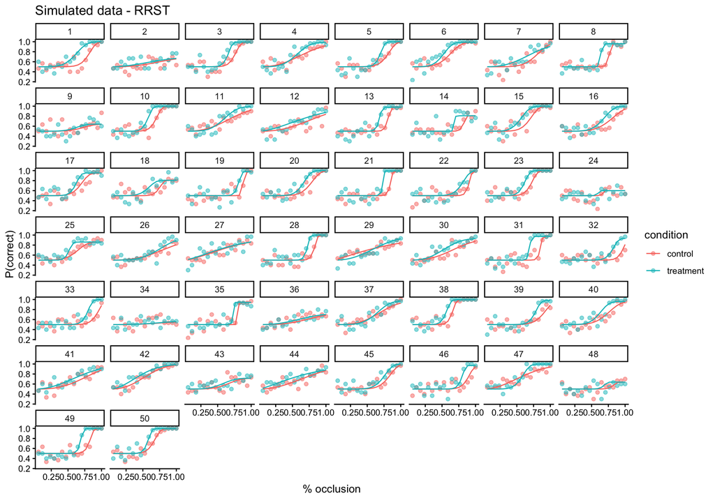

```r
sim_data_RRST %>%
  ggplot()+
  geom_point(aes(x = x/17, y = y/n, col = condition),alpha=.5)+
  geom_line(aes(x = x/17, y = theta, col=condition))+
  facet_wrap(~subj) +
  theme_classic()+
    labs(
    y='P(correct)',
    x='% occlusion',
    title='Simulated data - RRST'
  )
```

## BRMS model definition

Now in order to fit this data using BRMS we need to specify a model using *bf()*. In line with the paper, RRST data is modeled by a Weibull cumulative density function which has been modified to include a guess rate of 0.5 and a lapse rate lambda.

$$\frac{1}{2} + \left(\frac{1}{2} - \lambda\right) \cdot \left(1 -
e^{-\frac{x}{\alpha}^\beta} \right)$$

In BRMS syntax, this becomes the following code:

```r
bff_RRST =
  bf(
    y|trials(n) ~ (0.5 + (0.5-inv_logit(lambda)/2) * (1-exp(-(x/exp(alpha))^exp(beta)))),
    alpha ~ condition + (condition | subj),
    beta ~ condition + (condition | subj),
    lambda~ + (1 | subj),
    nl = TRUE,
    family=binomial(link="identity")
    )
```

We have specified random intercepts for all 3 parameters (threshold, slope and lambda) as well as main effects and random slopes for the effects of treatment on the threshold and slope.

We do not specify an effect of treatment on the lapse rate as it is a nuisance parameter. However, we let it vary by subject.

Two of the PF parameters need to be constrained because it would not make sense to let them vary from -Inf to +Inf. First, the slope parameter beta should be strictly positive to make sure the probability of response increases with the intensity of the stimulus. Second, the lapse rate parameter lambda should be constrained to the [0 0.5] range as it reflects the proportion of errors for extreme stimulus intensities. These constraints are enforced by transforms (*exp()* and *inv_logit()/2*) applied directly in the model equation.

Next we need to specify the prior. Here we provide two options: a weakly informative prior similar to the one we used to fit the VMP dataset or the empirically informed prior we derived from fitting the VMP dataset. In general, we recommend using the empirically informed prior as it should better stabilize sampling and inference.

```r
empirically_informed_priors_RRST = c(
  set_prior("normal(2.57,0.105)", class="b", nlpar="alpha", coef = "Intercept"),
  set_prior("normal(0,0.105)", class="b", nlpar="alpha", coef = "conditiontreatment"),
  set_prior("normal(2.05,0.85)", class="b", nlpar="beta", coef = "Intercept"),
  set_prior("normal(0,0.85)", class="b", nlpar="beta", coef = "conditiontreatment"),
  set_prior("normal(-4.51,2.53)", class="b", nlpar="lambda"),

  set_prior("normal(0.105,0.00746*10)", class="sd", nlpar="alpha", group = "subj", lb = 0),
  set_prior("normal(0.85,0.07*10)", class="sd", nlpar="beta", group = "subj", lb = 0),
  set_prior("normal(2.53,0.38)", class="sd", nlpar="lambda", group = "subj", lb = 0)
  )

weakly_informative_priors_RRST = c(
  set_prior("normal(1.5,0.5)", class="b", nlpar="alpha", coef = "Intercept"),
  set_prior("normal(0,0.5)", class="b", nlpar="alpha", coef = "conditiontreatment"),
  set_prior("normal(2,1)", class="b", nlpar="beta", coef = "Intercept"),
  set_prior("normal(0,1)", class="b", nlpar="beta", coef = "conditiontreatment"),
  set_prior("normal(-4,2)", class="b", nlpar="lambda"),

  set_prior("normal(0,0.5)", class="sd", nlpar="alpha", group = "subj", lb = 0),
  set_prior("normal(0,1)", class="sd", nlpar="beta", group = "subj", lb = 0),
  set_prior("normal(0,2)", class="sd", nlpar="lambda", group = "subj", lb = 0)
  )
```

## Model fitting

We can now fit the model to our (simulated) data. Here we include code to fit it with both types of priors but we will focus on the model fit with the empirically informed priors in the rest of this demo.

*Note: This might take some time*

```r
fit_eip_RRST <-
  brm(
    bff_RRST,
    data=sim_data_RRST,
    chains = 4,
    cores = 4,
    seed = seed,
    backend = "cmdstan",
    warmup=1000,
    iter=2000,
    control=list(
     adapt_delta=0.99,
     max_treedepth = 10
     ),
    prior = empirically_informed_priors_RRST
    )
```

```
## Running MCMC with 4 parallel chains...
```

```
## Chain 1 Rejecting initial value:
```

```
## Chain 1   Gradient evaluated at the initial value is not finite.
```

```
## Chain 1   Stan can't start sampling from this initial value.
```

```
## Chain 1 Iteration:    1 / 2000 [  0%]  (Warmup)
```

```
## Chain 2 Rejecting initial value:
```

```
## Chain 2   Gradient evaluated at the initial value is not finite.
```

```
## Chain 2   Stan can't start sampling from this initial value.
```

```
## Chain 2 Rejecting initial value:
```

```
## Chain 2   Gradient evaluated at the initial value is not finite.
```

```
## Chain 2   Stan can't start sampling from this initial value.
```

```
## Chain 2 Iteration:    1 / 2000 [  0%]  (Warmup)
```

```
## Chain 3 Rejecting initial value:
```

```
## Chain 3   Gradient evaluated at the initial value is not finite.
```

```
## Chain 3   Stan can't start sampling from this initial value.
```

```
## Chain 3 Rejecting initial value:
```

```
## Chain 3   Gradient evaluated at the initial value is not finite.
```

```
## Chain 3   Stan can't start sampling from this initial value.
```

[output not shown]

[output cut: 39 more lines]

[output not shown]

```r
# fit_wip_RRST <-
#   brm(
#     bff_RRST,
#     data=sim_data_RRST,
#     chains = 4,
#     cores = 4,
#     seed = seed,
#     backend = "cmdstan",
#     warmup=1000,
#     iter=2000,
#     control=list(
#      adapt_delta=0.99,
#      max_treedepth = 10
#      ),
#     prior = weakly_informative_priors_RRST
#   )
```

## Model diagnosing

No warning is popping up to tell us something went wrong with the sampler (i.e. problems with max_treedepth, divergent transitions, or E-BFMI). We can therefore have a look at the model. In case such a warning appears on your screen when you are running this code or analyzing your own data please refer to BRMS/Stan documentation (BRMS will give you a link corresponding to the issue you are facing).

```r
fit_eip_RRST
```

```
##  Family: binomial
##   Links: mu = identity
## Formula: y | trials(n) ~ (0.5 + (0.5 - inv_logit(lambda)/2) * (1 - exp(-(x/exp(alpha))^exp(beta))))
##          alpha ~ condition + (condition | subj)
##          beta ~ condition + (condition | subj)
##          lambda ~ +(1 | subj)
##    Data: sim_data_RRST (Number of observations: 1700)
##   Draws: 4 chains, each with iter = 2000; warmup = 1000; thin = 1;
##          total post-warmup draws = 4000
##
## Multilevel Hyperparameters:
## ~subj (Number of levels: 50)
##                                               Estimate Est.Error l-95% CI
## sd(alpha_Intercept)                               0.11      0.02     0.09
## sd(alpha_conditiontreatment)                      0.05      0.01     0.03
## sd(beta_Intercept)                                0.88      0.12     0.68
## sd(beta_conditiontreatment)                       0.28      0.11     0.04
## sd(lambda_Intercept)                              2.84      0.28     2.32
## cor(alpha_Intercept,alpha_conditiontreatment)     0.34      0.21    -0.10
## cor(beta_Intercept,beta_conditiontreatment)      -0.18      0.34    -0.76
##                                               u-95% CI Rhat Bulk_ESS Tail_ESS
## sd(alpha_Intercept)                               0.15 1.01      510     1126
## sd(alpha_conditiontreatment)                      0.07 1.00     1891     2719
## sd(beta_Intercept)                                1.14 1.00     1219     2050
## sd(beta_conditiontreatment)                       0.49 1.00      772      662
## sd(lambda_Intercept)                              3.43 1.00     2299     2695
## cor(alpha_Intercept,alpha_conditiontreatment)     0.72 1.00     1587     2628
## cor(beta_Intercept,beta_conditiontreatment)       0.58 1.00     2479     1654
##
## Regression Coefficients:
##                          Estimate Est.Error l-95% CI u-95% CI Rhat Bulk_ESS
## alpha_Intercept              2.63      0.02     2.59     2.67 1.01      353
## alpha_conditiontreatment    -0.16      0.01    -0.18    -0.14 1.00     1566
## beta_Intercept               1.99      0.14     1.73     2.26 1.01      738
## beta_conditiontreatment      0.03      0.09    -0.15     0.20 1.00     3038
## lambda_Intercept            -4.12      0.53    -5.20    -3.14 1.00      840
##                          Tail_ESS
## alpha_Intercept               807
## alpha_conditiontreatment     2252
## beta_Intercept               1431
## beta_conditiontreatment      2833
## lambda_Intercept             1473
##
## Draws were sampled using sample(hmc). For each parameter, Bulk_ESS
## and Tail_ESS are effective sample size measures, and Rhat is the potential
## scale reduction factor on split chains (at convergence, Rhat = 1).
```

checking these can be done with the following code.

```r
bfmi <- function(energy) {
  de <- diff(energy)
  var(de) / var(energy)
}

sp <- get_sampler_params(fit_eip_RRST$fit, inc_warmup = FALSE)

df <- do.call(rbind, lapply(seq_along(sp), function(i) {
  cbind(as.data.frame(sp[[i]]), chain = i)
}))


df %>% group_by(chain) %>% summarize(number_divergent = sum(divergent__),
                                     low_energy = bfmi(energy__) < 0.3,
                                     max_treedpeth = max(treedepth__))
```

```
## # A tibble: 4 × 4
##   chain number_divergent low_energy max_treedpeth
##   <int>            <dbl> <lgl>              <dbl>
## 1     1                0 FALSE                  7
## 2     2                0 FALSE                  7
## 3     3                0 FALSE                  8
## 4     4                0 FALSE                  8
```

## Model interpretation

Our model quantifies the effect of treatment on the threshold parameter alpha and the slope parameter beta of the psychometric function. To test whether there is such an effect, we can extract the posterior mean and 95% credible interval for the group-level difference between conditions and see if 0 is included in the interval. Alternatively, we can compute the posterior probability of this effect being larger than 0 and use this probability to compute a pseudo p-value for a two-sided test (i.e., H0 is that the effect is 0).

We demonstrate these two equivalent approaches in the following code:

```r
summary_stats_RRST<-
  as_draws_df(fit_eip_RRST) %>%
  select(b_alpha_Intercept,b_beta_Intercept,b_alpha_conditiontreatment,b_beta_conditiontreatment) %>%
  mutate(
    mean_alpha_treatment=b_alpha_Intercept+b_alpha_conditiontreatment,
    mean_beta_treatment=b_beta_Intercept+b_beta_conditiontreatment
  ) %>%
  rename(
    mean_alpha_control=b_alpha_Intercept,
    mean_beta_control=b_beta_Intercept,
    mean_alpha_diff=b_alpha_conditiontreatment,
    mean_beta_diff=b_beta_conditiontreatment
  ) %>%
  pivot_longer(everything()) %>%
  group_by(name) %>%
  summarise(
    m=mean(value),
    LB=quantile(value,0.025),
    UB=quantile(value,0.975),
    p_larger_than_0=mean(value>0),
    pseudo_p_value=2*min(p_larger_than_0,1-p_larger_than_0)
    )
```

```
## Warning: Dropping 'draws_df' class as required metadata was removed.
```

```r
print(summary_stats_RRST)
```

```
## # A tibble: 6 × 6
##   name                       m     LB     UB p_larger_than_0 pseudo_p_value
##   <chr>                  <dbl>  <dbl>  <dbl>           <dbl>          <dbl>
## 1 mean_alpha_control    2.63    2.59   2.67            1              0
## 2 mean_alpha_diff      -0.163  -0.182 -0.143           0              0
## 3 mean_alpha_treatment  2.47    2.42   2.51            1              0
## 4 mean_beta_control     1.99    1.73   2.26            1              0
## 5 mean_beta_diff        0.0257 -0.151  0.198           0.613          0.774
## 6 mean_beta_treatment   2.02    1.75   2.29            1              0
```

Here we need to warn you about a specificity of non-symmetrical PFs such as the Weibull or the Gumbell. For these functions, the slope parameter beta is a shape parameter rather than a dispersion/precision parameter like in the case of the Gaussian CDF. As a consequence the actual dispersion/precision/slope of the PF is set by both the threshold parameter alpha and the “slope” parameter beta.

Please see the `Mathematical rationale.Rmd` for how this can be shown using the equations of the psychometric weibull. In the markdown we show that the spread of the function scales linearly with the threshold $alpha$ parameter when beta is constant. This all makes the effects on parameter beta difficult to interpret.

Therefore we recommend that instead of testing effects on beta to test effects on the spread of the function. This quantity reflects the true dispersion of the function and can be interpreted in terms of precision/reliability similarly to the slope parameter of a Gaussian PF.

In the case of our simulated data, alpha changes but not beta and the spread is therefore different between the conditions (again as the spread inceases linearly with the alpha when beta is constant). We can compute the spread difference based on the parameters used to simulate the data (in arbitrary occlusion units):

```r
alpha_control=exp(mu_alpha_RRST)
alpha_treatment=exp(mu_alpha_RRST+mu_alpha_dif_RRST)

beta_control=exp(mu_beta_RRST)
beta_treatment=exp(mu_beta_RRST+mu_beta_dif_RRST)

spread_control=alpha_control*((-log(.1))^(1/beta_control)-(-log(.9))^(1/beta_control))
spread_treatment=alpha_treatment*((-log(.1))^(1/beta_treatment)-(-log(.9))^(1/beta_treatment))

true_spread_difference=spread_treatment-spread_control
print(true_spread_difference)
```

```
## [1] -0.6967851
```

We can also use the posterior samples from our model to estimate the spread difference and assess if it is “significant” i.e. different from 0. Here is some code to compute the posterior mean spread and corresponding 95% CI as well as the posterior probability of the spread difference being larger than 0 and a pseudo p-value for a two-sided test (i.e., H0 is that the effect is 0).

```r
spreads<-
  as_draws_df(fit_eip_RRST) %>%
  mutate(
    alpha_control=exp(b_alpha_Intercept),
    alpha_treatment=exp(b_alpha_Intercept+b_alpha_conditiontreatment),
    beta_control=exp(b_beta_Intercept),
    beta_treatment=exp(b_beta_Intercept+b_beta_conditiontreatment)
    ) %>%
  select(alpha_control,alpha_treatment,beta_control,beta_treatment) %>%
  pivot_longer(
    cols = everything(),
    names_to = c(".value", "condition"),
    names_sep = "_"
  ) %>%
  mutate(spread=alpha*((-log(0.1))^(1/beta)-(-log(0.9))^(1/beta)))
spreads_stats<-
  spreads %>%
  group_by(condition) %>%
  summarise(
    m=mean(spread),
    LB=quantile(spread,0.025),
    UB=quantile(spread,0.975)
    )

spread_diffs<-
  spreads %>%
  select(condition,spread) %>%
  mutate(draw=sort(rep(1:4000,2))) %>%
  pivot_wider(names_from = condition,values_from = spread) %>%
  mutate(difference=treatment-control)
spread_diffs_stats<-
  spread_diffs %>%
  summarise(
    name='spread_difference',
    m=mean(difference),
    LB=quantile(difference,0.025),
    UB=quantile(difference,0.975),
    p_larger_than_0=mean(difference>0),
    pseudo_p_value=2*min(p_larger_than_0,1-p_larger_than_0)
    )
print(spread_diffs_stats)
```

```
## # A tibble: 1 × 6
##   name                   m    LB     UB p_larger_than_0 pseudo_p_value
##   <chr>              <dbl> <dbl>  <dbl>           <dbl>          <dbl>
## 1 spread_difference -0.915 -1.72 -0.116          0.0125          0.025
```

Despite having no significant effect of treatment on parameter beta, we have a significant reduction of the spread by treatment. This corresponds to the parameters we used for simulations.

When we plot the group mean PFs later, we will see that, indeed, the treatment PF is steeper than the control one, indexing more precise or reliable perception under the treatment condition.

## Reporting the results

We could write something like this to report these results in a paper:

```r
sprintf(
  "Treatment led to a significant decrease of the threshold (mean [95%% CI] log(threshold) difference: %0.2f [%0.2f ; %0.2f] arbitrary occlusion units, pseudo p-value:  %0.3f), indexing increased sensitivity to occlusion under treatment (mean threshold for control: %0.2f%% [%0.2f%% ; %0.2f%%] occlusion; for treatment: %0.2f%% [%0.2f%% ; %0.2f%%]). Additionnaly, the spread of the function was also reduced (mean spread difference: %0.2f%% [%0.2f%% ; %0.2f%%] occlusion, pseudo p-value:  %0.3f), indicating increased precision of judgements made under treatment compared to control (mean spread for control: %0.2f%% [%0.2f%% ; %0.2f%%]; for treatment: %0.2f%% [%0.2f%% ; %0.2f%%]).",
  summary_stats_RRST$m[2],
  summary_stats_RRST$LB[2],
  summary_stats_RRST$UB[2],
  summary_stats_RRST$pseudo_p_value[2],

  100*exp(summary_stats_RRST$m[1])/17,
  100*exp(summary_stats_RRST$LB[1])/17,
  100*exp(summary_stats_RRST$UB[1])/17,

  100*exp(summary_stats_RRST$m[3])/17,
  100*exp(summary_stats_RRST$LB[3])/17,
  100*exp(summary_stats_RRST$UB[3])/17,

  100*spread_diffs_stats$m/17,
  100*spread_diffs_stats$LB/17,
  100*spread_diffs_stats$UB/17,
  spread_diffs_stats$pseudo_p_value,

  100*spreads_stats$m[1]/17,
  100*spreads_stats$LB[1]/17,
  100*spreads_stats$UB[1]/17,

  100*spreads_stats$m[2]/17,
  100*spreads_stats$LB[2]/17,
  100*spreads_stats$UB[2]/17
  )
```

```
## [1] "Treatment led to a significant decrease of the threshold (mean [95% CI] log(threshold) difference: -0.16 [-0.18 ; -0.14] arbitrary occlusion units, pseudo p-value:  0.000), indexing increased sensitivity to occlusion under treatment (mean threshold for control: 81.61% [78.72% ; 84.60%] occlu…
```

## Visualization

### Group mean differences

We can then construct plots that show the posterior distribution for the group-level differences in threshold and spread. We will also add a linerange materializing the 95% CI.

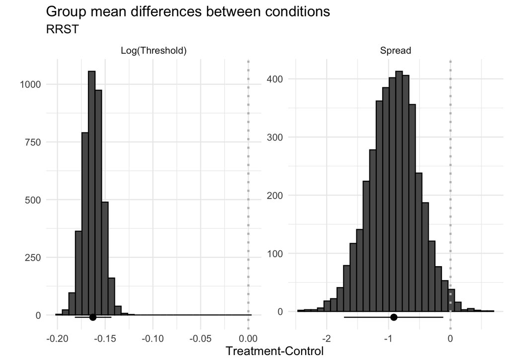

```r
spread_differences<-
  spread_diffs %>%
  select(difference)
summary_RRST_plot<-
  summary_stats_RRST %>%
  filter(name=='mean_alpha_diff') %>%
  full_join(spread_diffs_stats) %>%
  mutate(name=factor(name,c('mean_alpha_diff','spread_difference'),c('Log(Threshold)','Spread')))
as_draws_df(fit_eip_RRST) %>%
  select(b_alpha_conditiontreatment) %>%
  rename(mean_alpha_diff=b_alpha_conditiontreatment) %>%
  mutate(spread_difference=spread_differences$difference) %>%
  pivot_longer(everything()) %>%
  mutate(name=factor(name,c('mean_alpha_diff','spread_difference'),c('Log(Threshold)','Spread'))) %>%
  ggplot()+
  geom_histogram(aes(x=value),color='black')+
  geom_vline(aes(xintercept = 0),linetype='dotted',color='grey',linewidth=1)+
  geom_pointrange(data=summary_RRST_plot,aes(x=m,xmin=LB,xmax=UB,y=-10,group = name))+
  labs(
    title='Group mean differences between conditions',
    subtitle='RRST',
    x='Treatment-Control',
    y=''
    )+
  facet_wrap(.~name,scale='free')+
  theme_minimal()+
  theme(
    text=element_text(size = 12)
    )
```

### Group mean PF

To get a better sense of what these values mean, we can also plot the group average PFs.

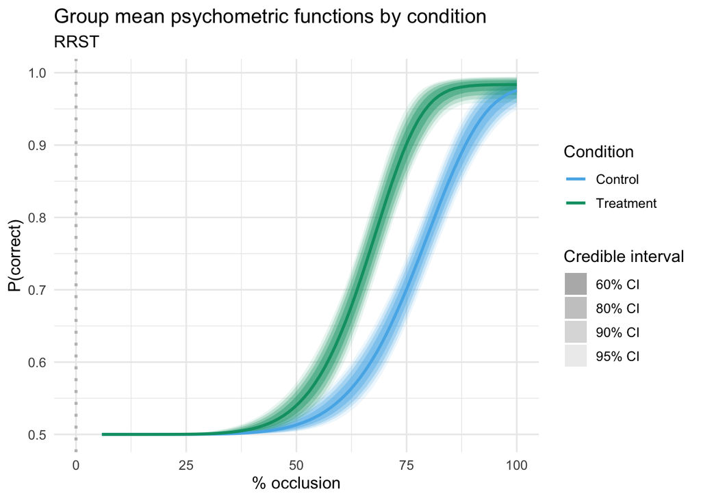

```r
# Get population-level draws
draws <- as_draws_df(fit_eip_RRST, variable = c(
  "b_alpha_Intercept", "b_alpha_conditiontreatment",
  "b_beta_Intercept", "b_beta_conditiontreatment",
  "b_lambda_Intercept"
)) %>%
  mutate(
    alpha_control = exp(b_alpha_Intercept),
    alpha_treatment = exp(b_alpha_Intercept + b_alpha_conditiontreatment),
    beta_control  = b_beta_Intercept,
    beta_treatment = b_beta_Intercept + b_beta_conditiontreatment,
    lambda = b_lambda_Intercept,
    beta_control = exp(beta_control),
    beta_treatment = exp(beta_treatment),
    lapse = inv_logit(lambda)
  )

# Estimate and summarize PF values at different x
x_seq <- seq(from = 1, to = 17, by = 0.2)
g <- expand.grid(.draw = 1:nrow(draws), x = x_seq, KEEP.OUT.ATTRS = FALSE)
draws$.draw <- 1:nrow(draws)

draw_long <- g %>%
  left_join(draws, by = ".draw") %>%
  mutate(
    p_control = 0.5 + (0.5 - lapse) * (1-exp(-(x/alpha_control)^beta_control)),
    p_treatment = 0.5 + (0.5 - lapse) * (1-exp(-(x/alpha_treatment)^beta_treatment)),
  ) %>%
  pivot_longer(
    cols = c(p_control, p_treatment),
    names_to = "condition",
    values_to = "p"
  ) %>%
  mutate(
    condition = recode(condition,
                       "p_control" = "Control",
                       "p_treatment" = "Treatment")
  )

# Summarise to CIs
pfs_ppc <- draw_long %>%
  group_by(x, condition) %>%
  summarise(
    s_lb_ci_95 = quantile(p, 0.025),
    s_ub_ci_95 = quantile(p, 0.975),
    s_lb_ci_90 = quantile(p, 0.05),
    s_ub_ci_90 = quantile(p, 0.95),
    s_lb_ci_80 = quantile(p, 0.1),
    s_ub_ci_80 = quantile(p, 0.9),
    s_lb_ci_60 = quantile(p, 0.20),
    s_ub_ci_60 = quantile(p, 0.80),
    m = median(p),
    .groups = "drop"
  ) %>%
  pivot_longer(
    cols = matches("s_(lb|ub)_ci_\\d+"),
    names_to = c("bound", "ci"),
    names_pattern = "s_(lb|ub)_ci_(\\d+)",
    values_to = "value"
  ) %>%
  pivot_wider(names_from = "bound", values_from = "value", names_prefix = "s_")

# Make plot
pfs_ppc %>%
  mutate(
    condition = ordered(condition, levels = c("Control", "Treatment")),
    ci = factor(ci, levels = c("60", "80", "90", "95"))
  ) %>%
  ggplot(aes(x = 100*x/17)) +
  geom_ribbon(aes(ymin = s_lb, ymax = s_ub, fill = condition, alpha = ci)) +
  geom_line(aes(y = m, color = condition), linewidth = 1) +
  geom_vline(xintercept = 0, linetype = "dotted", color = "grey", linewidth = 1) +
  scale_fill_manual(values = c("#56b4e9", "#009E73")) +
  scale_color_manual(values = c("#56b4e9", "#009E73")) +
  scale_alpha_manual(
    labels = c("60% CI", "80% CI", "90% CI", "95% CI"),
    values = c(.4, .3, .2, .1)
  ) +
  guides(

    fill = "none",
    alpha = guide_legend(order = 2),
    color = guide_legend(order = 1)
  ) +
  labs(
    title="Group mean psychometric functions by condition",
    subtitle='RRST',
    alpha = "Credible interval",
    color = "Condition",
    x = "% occlusion",
    y = 'P(correct)'
  ) +
  theme_minimal(base_size = 12)
```

### Individual participant PF

Finally, we should also have a look at individual participants’ psychometric functions to check they align with the data.

```r
pf <- function(x,alpha,beta,lambda){0.5 + (0.5-lambda) * (1-exp(-(x/alpha)^beta))}

t<-data.frame(coef(fit_eip_RRST)$subj[1:n_subj_RRST,1,]) %>%
  mutate(subj = 1:n_subj_RRST) %>%
  mutate(
    alpha_control = exp(alpha_Intercept),
    alpha_treatment = exp(alpha_Intercept+alpha_conditiontreatment),
    beta_control = exp(beta_Intercept),
    beta_treatment = exp(beta_Intercept+beta_conditiontreatment),
    lambda = inv_logit(lambda_Intercept) / 2,
  ) %>%
  select(alpha_control,alpha_treatment,beta_control,beta_treatment,lambda,subj) %>%
  pivot_longer(cols=!c(subj,lambda), names_to = c('parameter','condition'),names_sep = '_') %>%
  pivot_wider(names_from = parameter,values_from = value) %>%
  rowwise() %>%
  mutate(x = list(seq(1,17, by = 0.1))) %>%
  unnest() %>%
  mutate(p = pf(x,alpha,beta,lambda))
```

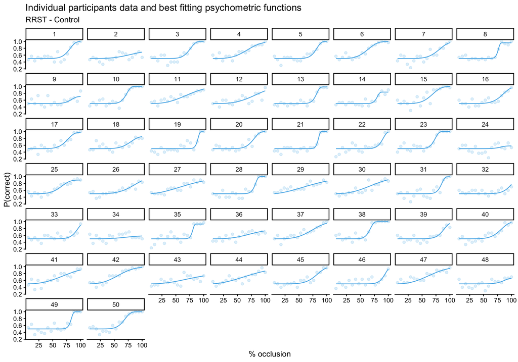

```r
t %>%
  filter(condition=='control') %>%
  ggplot()+
  geom_line(aes(x = 100*x/17, y = p),col="#56b4e9")+
  geom_point(data = filter(sim_data_RRST,condition=='control'), aes(x = 100*x/17, y = y/n,),alpha=.2,col="#56b4e9")+
  facet_wrap(~subj)+
  theme_classic()+
  labs(
    title='Individual participants data and best fitting psychometric functions',
    subtitle = 'RRST - Control',
    y='P(correct)',
    x = "% occlusion",
    )
```

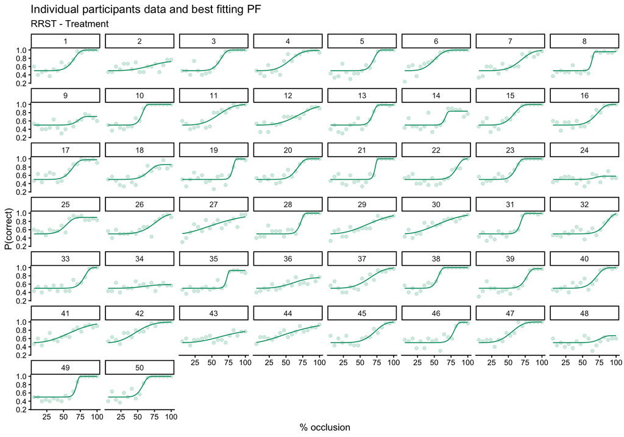

```r
t %>%
  filter(condition=='treatment') %>%
  ggplot()+
  geom_line(aes(x = 100*x/17, y = p),col="#009E73")+
  geom_point(data = filter(sim_data_RRST,condition=='treatment'), aes(x = 100*x/17, y = y/n,),alpha=.2,col="#009E73")+
  facet_wrap(~subj)+
  theme_classic()+
  labs(
    title='Individual participants data and best fitting PF',
    subtitle = 'RRST - Treatment',
    y='P(correct)',
    x = "% occlusion",
    )
```